# Cell tracking

Marion Hardy

2024-01-28

# Introduction

Electrotaxis on tricultures - 2 controls: points 01 and 03 - 2 electrotaxed: points 06 and 08

Tracked over 4 hours, with 49 frames

Points 3, 6 and 8 have not been adjusted for well sliding down throughout imaging. Could accoutn for that by filtering a minimum track length but the others measurements will be biased anyway.

```
##      LABEL     ID TRACK_ID QUALITY POSITION_X POSITION_Y POSITION_Z POSITION_T
## 1 ID161794 161794      785     523  1786.4971   775.4646          0          0
## 2 ID159745 159745      503     665  1192.7805   508.0812          0          0
## 3 ID157702 157702     1591     517  1706.5764   213.8414          0          0
## 4 ID157707 157707        4     566  2360.7332   212.3834          0          0
## 5 ID159755 159755      580     516  2241.9302   506.5930          0          0
## 6 ID163851 163851      998     454   231.5463   993.2885          0          0
##   FRAME   RADIUS VISIBILITY MANUAL_SPOT_COLOR MEAN_INTENSITY_CH1
## 1     0 12.90256          1                NA           2753.595
## 2     0 14.54909          1                NA           2769.325
## 3     0 12.82834          1                NA           1640.012
## 4     0 13.42250          1                NA           1902.348
## 5     0 12.81592          1                NA           2565.793
## 6     0 12.02134          1                NA           2059.438
##   MEDIAN_INTENSITY_CH1 MIN_INTENSITY_CH1 MAX_INTENSITY_CH1 TOTAL_INTENSITY_CH1
```

[output cut: 27 more lines]

```
##
##     0 1 2 3 4 5 6 7 8 9 10 11 12 13 14 15 16 17 18 19 20 21 22 23 24 25 26 27
##   0 1 1 1 1 1 1 1 1 1 1  1  1  1  1  1  1  1  1  1  1  1  1  1  1  1  1  1  1
##   1 1 1 1 1 1 1 1 1 1 1  1  1  1  1  1  1  1  1  1  1  1  1  1  1  1  1  1  1
##   2 1 1 1 1 1 1 1 1 1 1  1  1  1  1  1  1  1  1  1  1  1  1  1  1  1  1  1  1
##   3 1 1 1 1 1 1 1 1 1 1  1  1  1  1  1  1  1  1  1  1  1  1  1  1  1  1  1  1
##   4 1 1 1 1 1 1 1 1 1 1  1  1  1  1  1  1  1  1  1  1  1  1  1  1  1  1  1  1
##   5 1 1 1 1 1 1 1 1 1 1  1  1  1  1  1  1  1  1  1  1  1  1  1  1  1  1  1  1
##
##     28 29 30 31 32 33 34 35 36 37 38 39 40 41 42 43 44 45 46 47 48
##   0  1  1  1  1  1  1  1  1  1  1  1  1  1  1  1  1  1  1  1  1  1
##   1  1  1  1  1  1  1  1  1  1  1  1  1  1  1  1  1  1  1  1  1  1
##   2  1  1  1  1  1  1  1  1  1  1  1  1  1  1  1  1  1  1  1  1  1
##   3  1  1  1  1  1  1  1  1  1  1  1  1  1  1  1  1  1  1  1  1  1
##   4  1  1  1  1  1  1  1  1  1  1  1  1  1  1  1  1  1  1  1  1  1
##   5  1  1  1  1  1  1  1  1  1  1  1  1  1  1  1  1  1  0  0  0  0
```

TRACK_ID is the reference to the track, the number of time it appears is the number of frames it was tracked through. Every line is the track, its frame and the characteristics of the cell being tracked (area, circularity, intensity, …)

# Spider plotting the tracks if possible

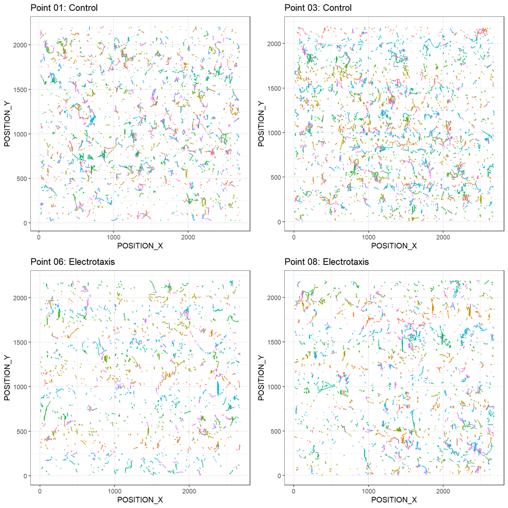

## Centering the tracks to 0,0

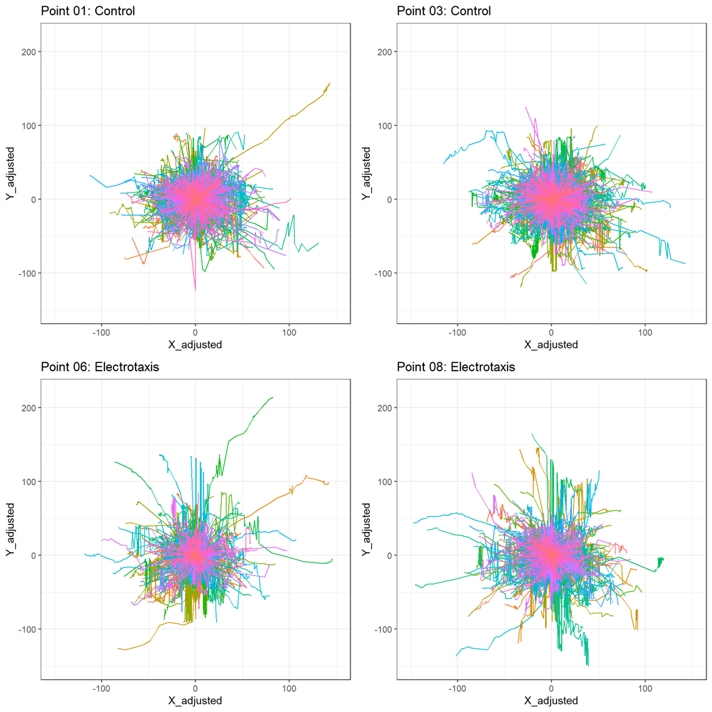

# Let’s get some numbers on that

## Checking average displacement

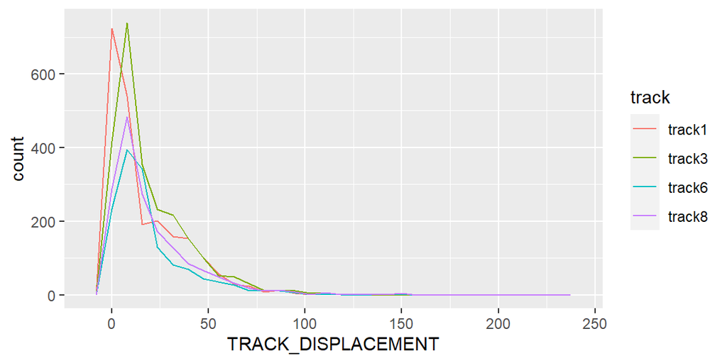

More cells are moving in the controls but they are moving lesser distances. NB: This isn’t normalized to the total amount of cells tracked per condition.

## Get some stats

### Wilcoxon test with group control (less permissive than t test because non parametric)

Maybe the appropriate test would be a Mann-Whitney if we consider the samples independent

I’m asking the question: Is CTRL parameter LESSER than electrotaxis??

```
## # A tibble: 1 × 8
##   .y.                group1  group2          n1    n2 statistic       p p.signif
##   <chr>              <chr>   <chr>        <int> <int>     <dbl>   <dbl> <chr>
## 1 TRACK_DISPLACEMENT control electrotaxis  4607  3059   6576229 3.62e-7 ****
```

```
## # A tibble: 1 × 8
##   .y.                     group1  group2       n1    n2 statistic     p p.signif
##   <chr>                   <chr>   <chr>     <int> <int>     <dbl> <dbl> <chr>
## 1 TOTAL_DISTANCE_TRAVELED control electrot…  4607  3059   7388178     1 ns
```

```
## # A tibble: 1 × 8
##   .y.                      group1 group2    n1    n2 statistic        p p.signif
##   <chr>                    <chr>  <chr>  <int> <int>     <dbl>    <dbl> <chr>
## 1 LINEARITY_OF_FORWARD_PR… contr… elect…  4607  3059   6213176 7.92e-19 ****
```

```
## # A tibble: 1 × 8
##   .y.                         group1 group2    n1    n2 statistic     p p.signif
##   <chr>                       <chr>  <chr>  <int> <int>     <dbl> <dbl> <chr>
## 1 MEAN_DIRECTIONAL_CHANGE_RA… contr… elect…  4171  2852   7276232     1 ns
```

```
## # A tibble: 1 × 8
##   .y.              group1  group2          n1    n2 statistic     p p.signif
##   <chr>            <chr>   <chr>        <int> <int>     <dbl> <dbl> <chr>
## 1 TRACK_MEAN_SPEED control electrotaxis  4607  3059   8415632     1 ns
```

### Violin plots of motion parameters

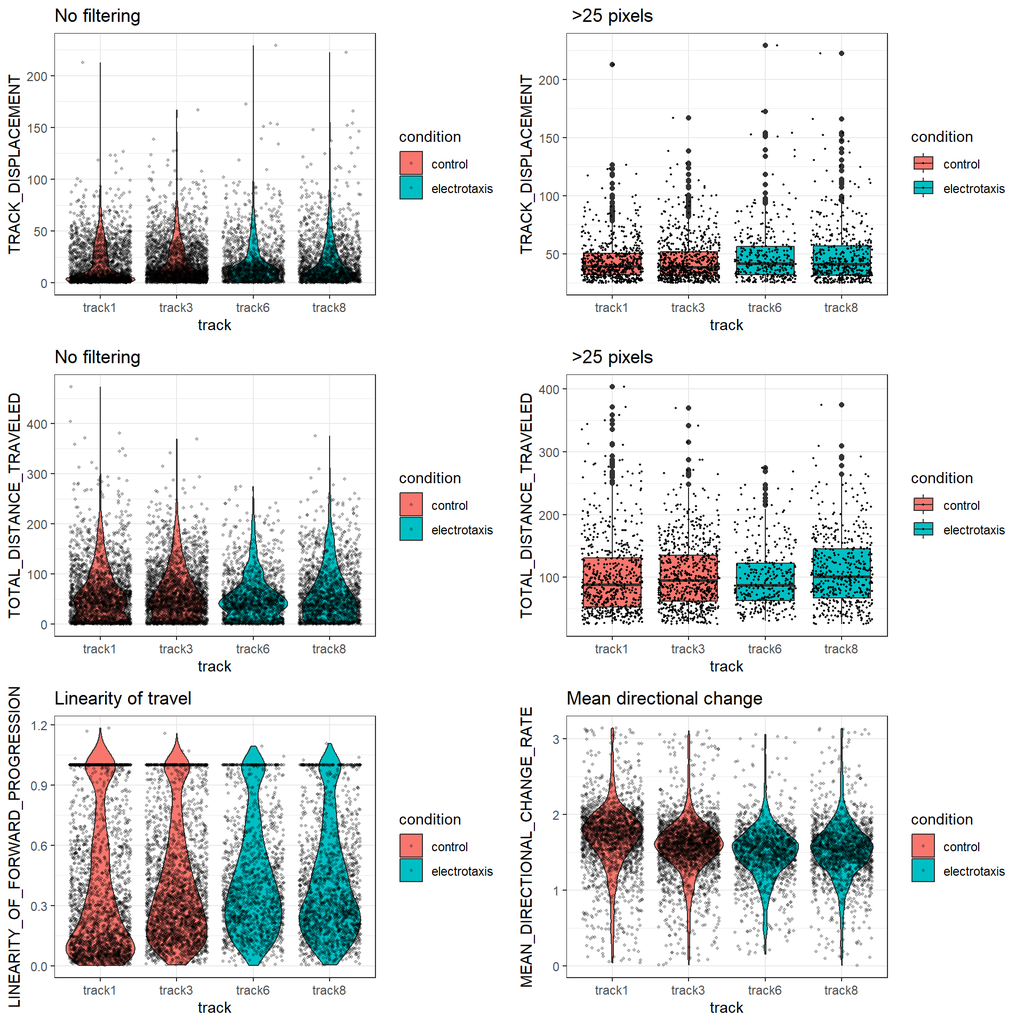

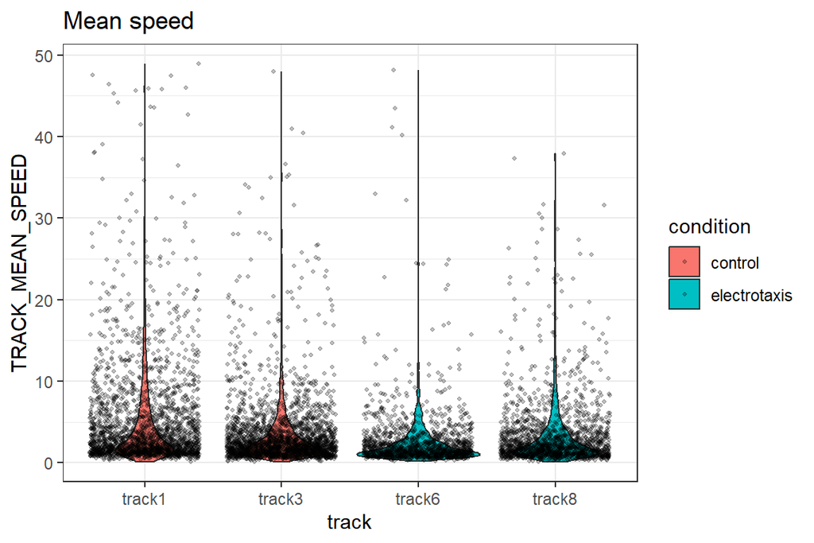

- TRACK_DISPLACEMENT: length of the vector between first frame point coordinates and last frame point coordinates
- TOTAL_DISTANCE_TRAVELED: total length of cell track
- LINEARITY OF FORWARD PROGRESSION : Linearity of travel = mean straight line speed /track mean speed.
- MEAN_DIRECTIONAL_CHANGE_RATE :measures the angle between two succeeding links, averaged over all the links of a track

# Conclusions

**Control condition** :

- More speed

- More directional changes

- More total distance traveled

**Electrotaxis** :

- More displacement (cells are going further away)

- More linear in their motion

**Looks like in the control condition, cell are sort of patrolling around with high speed but no orientation whereas the “electrotaxed” cells move more purposefuly but slower.**